# Workshop 01

# 1 Introduction

Today you will get some review of topics we have covered recently. The Console window will display executed code output and can also be used for quick code execution. However, any work done in the Console window will be lost once you exit RStudio.

We will use package `ggplot2` from `tidyverse`; so let’s load `tidyverse` now with

```r
library(tidyverse)
```

It is good practice to load all packages you will use at the start of your R Markdown document.

# 2 Console computation

The console can be used as a calculator.

- addition: `+`
- subtraction: `-`
- division: `/`
- multiplication: `*`
- modulus: `%%`
- integer division: `%/%`
- raise to power: `^`

**Evaluate the following expressions in the Console window.**

1. `3 + 4 * 0 - (100 / 3)`
2. `(4 + 6) * (2 ^ 6)`
3. `1 / 0`
4. `10 ^ 10 ^ 10 ^ 10`
5. `0 / 0`
6. `0.0000003 * 2`

When you launch RStudio, numerous functions are immediately available to you. A few of the mathematical and statistical functions are:

| R function | Purpose |
| --- | --- |
| `abs()` | absolute value |
| `sin()` | sine |
| `cos()` | cosine |
| `tan()` | tangent |
| `log()` | logarithm |
| `exp()` | exponential |
| `mean()` | arithmetic mean |
| `median()` | median |
| `sd()` | standard deviation |

**Evaluate the following expressions in the Console window.**

7. `abs(7)`
8. `sin(3.1415)`
9. `exp(1)`
10. logarithm of expressions 1 - 6

What logarithm did you just take? Was it the natural log, base 10, base 2? **Type `?log` in the console.** A question mark that precedes a function’s name or built in data object will populate the help tab.

Natural log.

**Type the following in the Console window.**

11. `?sd`
12. `?mtcars`
13. `?longley`

**What are `mtcars` and `longley`?**

The most important aspects of R’s help resource will be the description and examples given. Examples are always at the end of the help reference. **How many examples are given in the help of `sd`?**

14. Run the example provided in the help for `sd`.

**Investigate what the following functions do by creating an R chunk with** **examples of each function in use.**

15. `sqrt`
16. `round`
17. `floor`
18. `ceiling`

```r
sqrt(2)
```

```
[1] 1.414214
```

```r
round(2.5)
```

```
[1] 2
```

```r
round(2.51)
```

```
[1] 3
```

```r
floor(2.5)
```

```
[1] 2
```

```r
ceiling(2.5)
```

```
[1] 3
```

Now is good place to save your work. Stage, commit, and push your work to GitHub. Did you remember to configure git?

```r
library(usethis)
use_git_config(user.name = "", user.email = "")
```

# 3 Longley data

## 3.1 Examine the data

Consider Longley’s Economic Regression Data. This data set is built-in to R. That means it is available immediately once RStudio is launched. Type `longley` in your Console to see the entire data set. The same data is given below.

|  | GNP.deflator | GNP | Unemployed | Armed.Forces | Population | Year | Employed |
| --- | --- | --- | --- | --- | --- | --- | --- |
| 1947 | 83.0 | 234.289 | 235.6 | 159.0 | 107.608 | 1947 | 60.323 |
| 1948 | 88.5 | 259.426 | 232.5 | 145.6 | 108.632 | 1948 | 61.122 |
| 1949 | 88.2 | 258.054 | 368.2 | 161.6 | 109.773 | 1949 | 60.171 |
| 1950 | 89.5 | 284.599 | 335.1 | 165.0 | 110.929 | 1950 | 61.187 |
| 1951 | 96.2 | 328.975 | 209.9 | 309.9 | 112.075 | 1951 | 63.221 |
| 1952 | 98.1 | 346.999 | 193.2 | 359.4 | 113.270 | 1952 | 63.639 |
| 1953 | 99.0 | 365.385 | 187.0 | 354.7 | 115.094 | 1953 | 64.989 |
| 1954 | 100.0 | 363.112 | 357.8 | 335.0 | 116.219 | 1954 | 63.761 |
| 1955 | 101.2 | 397.469 | 290.4 | 304.8 | 117.388 | 1955 | 66.019 |
| 1956 | 104.6 | 419.180 | 282.2 | 285.7 | 118.734 | 1956 | 67.857 |

[output cut: 6 more lines]

```
[1] 16  7
```

**Answer the following questions about the `longley` data set.**

1. How many rows and columns does `longley` have?

16, 7

2. What do you think is the difference between the first column of years and the column with the label Year?

One has a column label, the other doesn’t.

**Type `head(longley)` in the Console window. What does this do?** First few rows printed **How about `tail(longley)`?** Last few rows printed

## 3.2 Summary statistics

Data set `longley` is stored in R as a data frame. Each column is a vector with the components being of the same variable type. We will learn about these details later this week. For now, to access a specific vector use `longley$variable_name`, where `variable_name` is one of the variables in `longley`. For example,

```r
longley$GNP
```

```
 [1] 234.289 259.426 258.054 284.599 328.975 346.999 365.385 363.112 397.469
[10] 419.180 442.769 444.546 482.704 502.601 518.173 554.894
```

and

```r
longley$Year
```

```
 [1] 1947 1948 1949 1950 1951 1952 1953 1954 1955 1956 1957 1958 1959 1960 1961
[16] 1962
```

give the GNP and Year vectors of data, respectively.

**In a new code chunk below get the following vectors:**

3. Unemployed
4. Population
5. Employed

```r
longley$Unemployed
```

```
 [1] 235.6 232.5 368.2 335.1 209.9 193.2 187.0 357.8 290.4 282.2 293.6 468.1
[13] 381.3 393.1 480.6 400.7
```

```r
longley$Population
```

```
 [1] 107.608 108.632 109.773 110.929 112.075 113.270 115.094 116.219 117.388
[10] 118.734 120.445 121.950 123.366 125.368 127.852 130.081
```

```r
longley$Employed
```

```
 [1] 60.323 61.122 60.171 61.187 63.221 63.639 64.989 63.761 66.019 67.857
[11] 68.169 66.513 68.655 69.564 69.331 70.551
```

**In another code chunk compute the mean, median, and standard deviation for** **each of the vectors in 3 - 5.**

The `summary` function in R will give you many of these statistics. For example,

```r
summary(longley$GNP)
```

```
   Min. 1st Qu.  Median    Mean 3rd Qu.    Max.
  234.3   317.9   381.4   387.7   454.1   554.9
```

gives us the minimum, maximum, mean, and quartiles of the GNP vector of data.

**Insert a code chunk and use the `summary` function on two variables of** **your choice in `longley`.**

```r
summary(longley$Unemployed)
```

```
   Min. 1st Qu.  Median    Mean 3rd Qu.    Max.
  187.0   234.8   314.4   319.3   384.2   480.6
```

```r
summary(longley$Population)
```

```
   Min. 1st Qu.  Median    Mean 3rd Qu.    Max.
  107.6   111.8   116.8   117.4   122.3   130.1
```

```r
summary(longley$Employed)
```

```
   Min. 1st Qu.  Median    Mean 3rd Qu.    Max.
  60.17   62.71   65.50   65.32   68.29   70.55
```

Now is good place to save your work. Stage, commit, and push your work to GitHub.

## 3.3 Employment investigation

Suppose it is 1962. Two economists are discussing employment. Each makes the following claim.

**Economist A:** Employment has never been higher in the past 15 years, we have seen a gradual increase from 1947 to 1962.

**Economist B:** Employment has been range bound since 1947 and is at its lowest level since 1947.

**Which economist is correct?**

Let’s look at the variable Employed across time using function `ggplot()`.

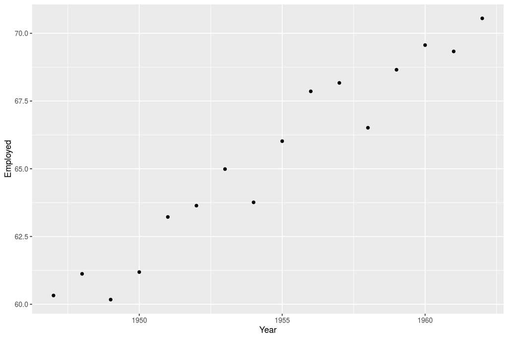

```r
ggplot(data = longley, mapping = aes(x = Year, y = Employed)) +
  geom_point()
```

Is this the best way to look at employment over time? What other variables in the data are changing as we progress from 1947 - 1962? Discuss this with those near you. How would you create a more meaningful representation of employment over time?

Population is also changing, so let’s graph as % employed.

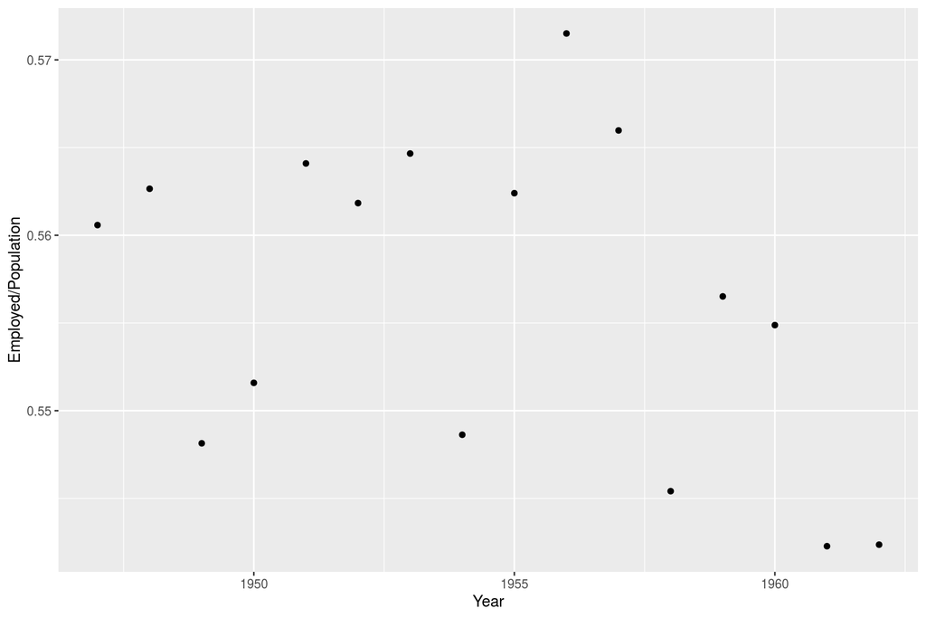

```r
ggplot(data = longley, mapping = aes(x = Year, y = Employed/Population)) +
  geom_point()
```

**Based on your discussions, which economist do you think is correct?**

The second economist; % employed is at its lowest.

Use package `ggplot2` to recreate the plots below.

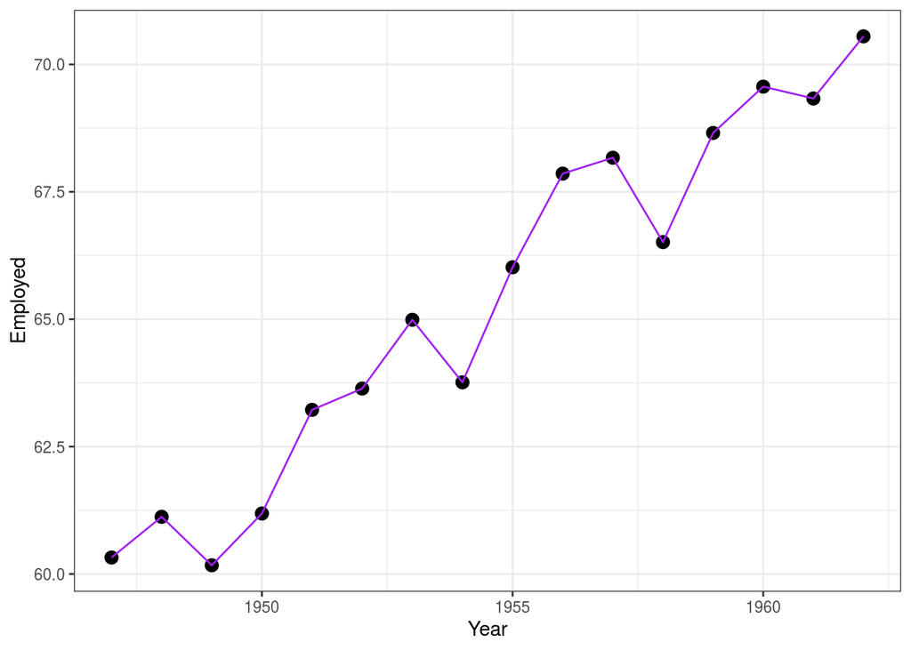

```r
ggplot(data = longley, mapping = aes(x = Year, y = Employed)) +
  geom_point(size = 3) + geom_line(color = "purple") + theme_bw()
```

*Hints:*

- color is “purple”
- size is 3
- theme is `theme_bw()`

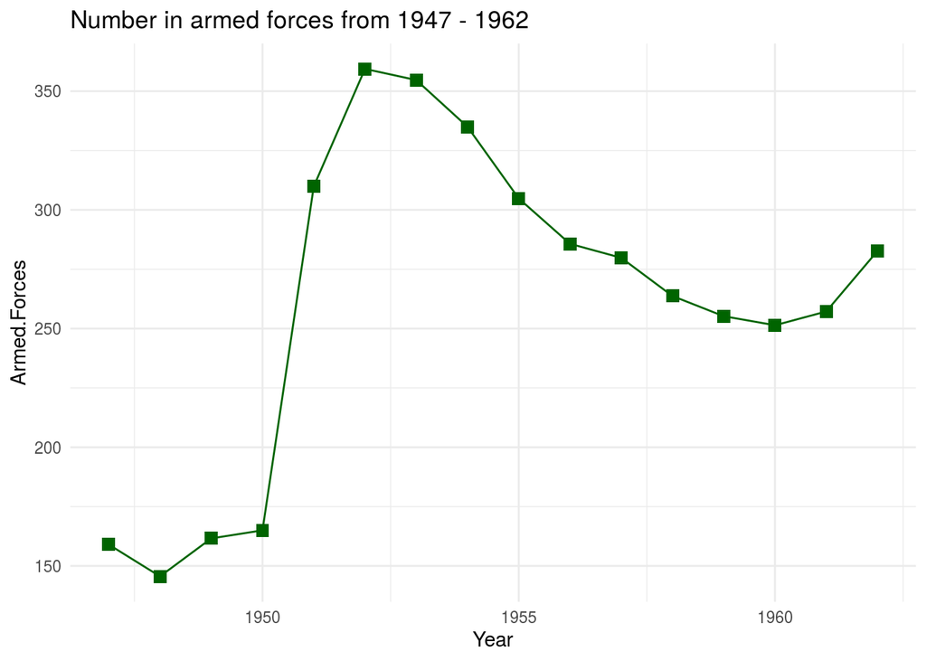

```r
ggplot(data = longley, mapping = aes(x = Year, y = Armed.Forces)) +
  geom_point(size = 3, shape = "square", color = "darkgreen") + geom_line(color = "darkgreen") + theme_minimal() + ggtitle("Number in armed forces from 1947 - 1962")
```

*Hints:*

- color is “darkgreen”
- size is 3
- shape is “square”
- theme is `theme_minimal()`

**Why the sudden jump in number of armed forces members from 1950 to 1951?**

Use `longley` to create one plot of your choice. Be sure to choose an appropriate representation for the variable(s) given the variable type(s) - quantitative or qualitative.

# 4 Final look over

Before you make your final commit and push, check that

1. all your code chunks have names,
2. your plots are of appropriate dimensions,
3. you have included written responses to the relevant questions.

Make your final stage, commit, and push. Verify your work is updated on GitHub.

# 5 References

1. J. W. Longley (1967) An appraisal of least-squares programs from the point of view of the user. Journal of the American Statistical Association 62, 819-841.